# Rejection Sampling and Importance Sampling

Statistical Computing for Data Analysis

# Where we are in the course

So far, we have mostly relied on:

- Built-in samplers like `rnorm()`, `rpois()`, `runif()`, …
- **Inverse transform sampling** (Inverse CDF method): works great **when you can compute the inverse CDF** $F^{-1}(u)$.

But in practice, you often face one (or more) of these problems:

1. You *can evaluate a density* $f(x)$, but you **cannot invert** the CDF.
2. The event you care about is **rare**, so naive simulation wastes most samples.

Today: two practical tools for these situations.

# Outline

1. Rejection sampling (to *generate* data when no inverse CDF is available)
2. Importance sampling (to *estimate* expectations/probabilities efficiently, especially rare events)

# A quick decision guide (preview)

**Goal: Generate *independent* draws from a distribution**

- If you know $F^{-1}$: **Inverse transform**
- If you *can bound* $f(x)$ by a scaled proposal: **Rejection sampling**

**Goal: Estimate $E[h(X)]$ or $P(X \in A)$**

- If $A$ is rare under your simulator: **Importance sampling**

# Rejection sampling: when and why

**When to use it**

You want to simulate from a target density $f(x)$ but:

- $F^{-1}$ is not available (no closed-form quantile function)
- you can still evaluate $f(x)$ up to a constant, i.e. $f(x) \propto \tilde f(x)$

**Key idea**

Sample from an easier proposal distribution $g(x)$, then *accept* a draw with some probability so that accepted values follow the target.

# Rejection sampling: the algorithm

Assume:

- You can sample from a proposal density $g(x)$
- You can compute an unnormalized target $\tilde f(x)$
- You can find a constant $M$ such that for all $x$ in the support:
  $$\tilde f(x) \le M g(x).$$

Algorithm:

1. Draw $Y \sim g$
2. Draw $U \sim \text{Uniform}(0,1)$
3. Accept $Y$ if
   $$U \le \frac{\tilde f(Y)}{M g(Y)}.$$
4. Repeat until you have $n$ accepted draws

**Practical note:** The acceptance rate is about $1/M$ (higher is better).

# Rejection sampling example: a “weird” density with no inverse CDF

Target density on $[-2,2]$:
$$f(x) \propto \exp(-x^4), \quad -2 \le x \le 2.$$

- This is a valid density after normalization (but we don’t need the normalizing constant).
- The CDF has no simple closed form, so inverse transform is not convenient.
- Easy proposal: Uniform$(-2,2)$.

Because $\tilde f(x) = \exp(-x^4) \le 1$ and $g(x)=1/4$, we can use $M=4$.

# Rejection sampler in base R

```r
set.seed(4279)

f_tilde <- function(x) exp(-x^4)                # unnormalized target
g_samp  <- function(n) runif(n, min=-2, max=2)  # proposal sampler
g_dens  <- function(x) dunif(x, min=-2, max=2)  # proposal density

rej_samp <- function(n, M = 4) {
  out <- numeric(0)
  n_try <- 0

  while (length(out) < n) {
    y <- g_samp(1)
    u <- runif(1)
    n_try <- n_try + 1

    # acceptance probability = f_tilde(y) / (M * g(y))
    # Here it simplifies to exp(-y^4).
    if (u <= f_tilde(y) / (M * g_dens(y))) out <- c(out, y)
  }

  list(draws = out, acceptance_rate = n / n_try)
}

sim <- rej_samp(5000)
sim$acceptance_rate
```

```
## [1] 0.4593477
```

# Visual check: histogram vs (scaled) density

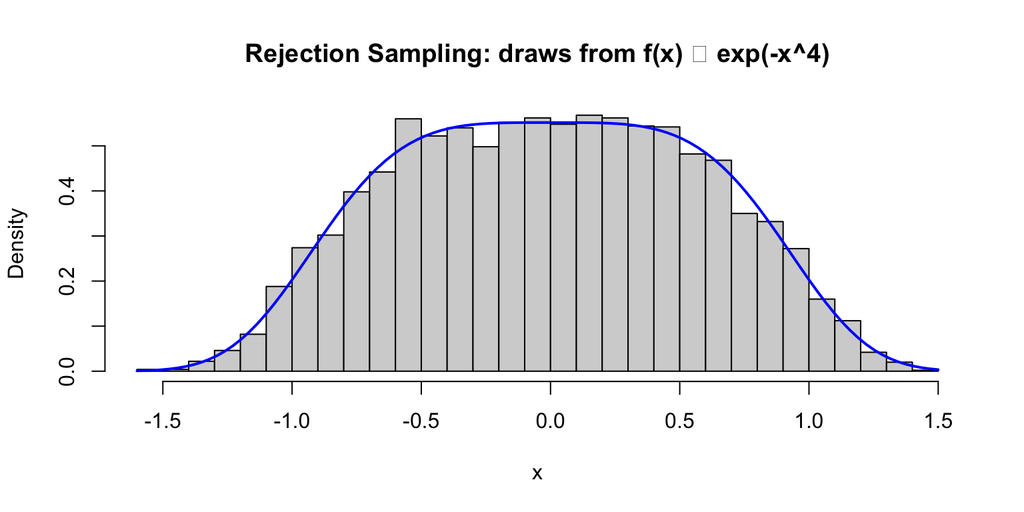

```r
x <- seq(-2, 2, length.out = 400)

hist(sim$draws, breaks = 40, freq = FALSE, col = "lightgray",
     main = "Rejection Sampling: draws from f(x) ∝ exp(-x^4)",
     xlab = "x")

# Overlay a *scaled* version of the unnormalized density (for shape only)
curve(f_tilde(x) / integrate(f_tilde, -2, 2)$value, add = TRUE, lwd = 2, col = "blue")
```

# Rejection sampling: practical tips and pitfalls

**Choosing the proposal $g$**

- A *bad* proposal (too narrow, wrong location) forces a large $M$ → very low acceptance
- A *good* proposal looks like the target (same support, similar shape)

**Red flags in practice**

- Acceptance rate is tiny (e.g., < 1%)
- You keep rejecting values in certain regions → proposal mismatch

**Takeaway:** Rejection sampling is great for generating data, but can become inefficient in higher dimensions or with poor proposals.

# Importance sampling: when and why

**When to use it**

You want to estimate an expectation or probability under a target distribution, e.g.

- $E_f[h(X)]$
- $P(X \in A)$

and naive simulation is inefficient, especially if:

- $A$ is a *rare event*
- $f(X)$ is dominated by tail behavior

**Key idea**

Simulate from a different distribution that visits “important” regions more often, and then reweight.

# Importance sampling: the rare-event problem

Suppose we care about a **very rare event**, like:

- a system failure that happens about **1 in 10,000** runs
- an extreme loss in finance
- a “once in a long time” tail outcome

If we simulate *normally* (from the usual model), almost every simulated run is a **non-failure**.

That means:

- we spend lots of compute/time generating “boring” samples
- our estimate of failure probability is noisy because we see few (or zero) failures

# Importance sampling: the basic idea

Instead of sampling under “typical conditions,” we:

1. **Intentionally over-sample high-risk conditions** where failures are more likely
2. **Down-weight** those high-risk samples so we don’t exaggerate the overall risk

So we get:

- **more information** about the rare event per simulation run
- a **much faster** (often far less variable) estimate of the true risk

# A helpful mental picture

- Standard simulation: “look for a needle in a haystack”
- Importance sampling: “sample from a smaller pile where needles are more common”

But after we collect needles from the smaller pile, we correct for the fact that we **looked in a biased place** by applying **weights**.

# Importance sampling: what is a weight?

A **weight** is a correction factor that says:

> “How much should this sample count when estimating the original probability?”
- Samples drawn from **high-risk** conditions usually get **small weights**
- Samples drawn from **typical** conditions get **larger weights**

You can think of weights as undoing the bias introduced by “oversampling risk.”

**Our Goal**: estimate an average or probability under the original model $f(x)$:
$$\mu = \mathbb{E}_{f}[h(X)].$$

We simulate from a different model $g(x)$ and correct with weights:
$$\mu
= \int h(x)\,f(x)\,dx
= \int h(x)\,\frac{f(x)}{g(x)}\,g(x)\,dx
=
\mathbb{E}_{g}\left[h(X)\,\underbrace{\frac{f(X)}{g(X)}}_{\text{weight}}\right].$$

That’s all: **sample from $g$**, then **reweight** to estimate under $f$.

# Practical guidance: choosing the “high-risk sampler”

Your “high-risk” sampling distribution should:

- put more probability where the rare event happens (so you actually see it)
- still cover all the important regions of the original model

Rule of thumb for tail events:

- If the proposal has **lighter tails** than the original, weights can become **huge**
- Huge weights → one or two samples dominate → estimates become unstable

# Common pitfall (what can go wrong)

**Bad choice:** your high-risk sampler avoids some region where the original model can go.

Result:

- weights can “explode”
- variance can get **worse** than standard Monte Carlo

In practice, you should always check:

- Do a few weights dominate?
- Does the estimate jump around a lot when you rerun?

# Importance sampling example: estimating a rare event probability

Target: $Z \sim N(0,1)$. We want
$$p = P(Z > 4).$$

This is rare (about 3e-5), so with naive sampling you might see **zero** events unless $n$ is huge.

Proposal: $Z \sim N(\mu, 1)$ with $\mu=4$, so we generate more tail values near 4.

# Naive Monte Carlo vs importance sampling

```r
set.seed(4279)
n <- 50000
threshold <- 4

# True value (for checking only)
p_true <- 1 - pnorm(threshold)

# 1) Naive MC: Z ~ N(0,1)
z_naive <- rnorm(n)
p_hat_naive <- mean(z_naive > threshold)

# 2) Importance sampling: sample from N(mu,1)
mu <- 4
z_is <- rnorm(n, mean = mu, sd = 1)

# weights: f/g = dnorm(z;0,1) / dnorm(z;mu,1)
w <- dnorm(z_is, mean = 0, sd = 1) / dnorm(z_is, mean = mu, sd = 1)

p_hat_is <- mean((z_is > threshold) * w)

c(p_true = p_true, naive = p_hat_naive, importance = p_hat_is)
```

```
##       p_true        naive   importance
## 3.167124e-05 2.000000e-05 3.158224e-05
```

# A quick diagnostic: effective sample size (ESS)

Importance sampling can fail if weights are extremely variable.

A simple diagnostic is the **effective sample size**:
$$\text{ESS} = \frac{\left(\sum_i w_i\right)^2}{\sum_i w_i^2}.$$

- ESS close to $n$: weights are stable
- ESS much smaller than $n$: many weights are near zero and a few dominate

```r
ess <- (sum(w)^2) / sum(w^2)
c(n = n, ESS = ess, ESS_fraction = ess/n)
```

```
##            n          ESS ESS_fraction
## 5.000000e+04 6.514954e+00 1.302991e-04
```